# Final Project

Nurul Syafiqah Mohammad Hamdi

Due Date: 12/13/2020

```r
rm(list = ls() ) ## cleans up your R environment

# load packages
library(dplyr)
library(tidyr)
library(ggplot2)
```

```r
setwd("~/Downloads/2020 Primary Precinct Results")
```

```
The working directory was changed to /Users/syafiqahhamdi/Downloads/2020 Primary Precinct Results inside a notebook chunk. The working directory will be reset when the chunk is finished running. Use the knitr root.dir option in the setup chunk to change the working directory for notebook chunks.
```

```r
Covid19 <- read.csv("Provisional_COVID-19_Death_Counts_in_the_United_States_by_County.csv", header= TRUE)
```

```r
Policy <- read.csv("https://healthdata.gov/sites/default/files/state_policy_updates_20201114_0719.csv")
```

## Inspecting The Data Process

```r
head(Covid19)
```

|  | Date.as.of | First.week | Last.week | State | County.name | FIPS.County.Code | Urban.Rural.Code | Deaths.involving.COVID.19 | Deaths.from.All.Causes |
| --- | --- | --- | --- | --- | --- | --- | --- | --- | --- |
| 1 | 11/12/2020 | 02/01/2020 | 11/07/2020 | AK | Anchorage Borough | 2020 | Medium metro | 53 | 1622 |
| 2 | 11/12/2020 | 02/01/2020 | 11/07/2020 | AK | Fairbanks North Star Borough | 2090 | Small metro | 16 | 388 |
| 3 | 11/12/2020 | 02/01/2020 | 11/07/2020 | AL | Autauga County | 1001 | Medium metro | 27 | 397 |
| 4 | 11/12/2020 | 02/01/2020 | 11/07/2020 | AL | Baldwin County | 1003 | Small metro | 89 | 1720 |
| 5 | 11/12/2020 | 02/01/2020 | 11/07/2020 | AL | Barbour County | 1005 | Noncore | 14 | 213 |
| 6 | 11/12/2020 | 02/01/2020 | 11/07/2020 | AL | Bibb County | 1007 | Large fringe metro | 19 | 149 |

```r
glimpse(Covid19)
```

```
Rows: 1,294
Columns: 9
$ Date.as.of                <chr> "11/12/2020", "11/12/2020", "11/12/2020", "11/12/2020", "11/12/2020", "11/12/2020", "11/1…
$ First.week                <chr> "02/01/2020", "02/01/2020", "02/01/2020", "02/01/2020", "02/01/2020", "02/01/2020", "02/0…
$ Last.week                 <chr> "11/07/2020", "11/07/2020", "11/07/2020", "11/07/2020", "11/07/2020", "11/07/2020", "11/0…
$ State                     <chr> "AK", "AK", "AL", "AL", "AL", "AL", "AL", "AL", "AL", "AL", "AL", "AL", "AL", "AL", "AL",…
$ County.name               <chr> "Anchorage Borough", "Fairbanks North Star Borough", "Autauga County", "Baldwin County", …
$ FIPS.County.Code          <int> 2020, 2090, 1001, 1003, 1005, 1007, 1009, 1013, 1015, 1017, 1019, 1021, 1023, 1027, 1031,…
$ Urban.Rural.Code          <chr> "Medium metro", "Small metro", "Medium metro", "Small metro", "Noncore", "Large fringe me…
$ Deaths.involving.COVID.19 <int> 53, 16, 27, 89, 14, 19, 12, 27, 109, 10, 10, 18, 10, 29, 14, 44, 58, 26, 36, 53, 46, 26, …
$ Deaths.from.All.Causes    <int> 1622, 388, 397, 1720, 213, 149, 393, 175, 1246, 293, 236, 316, 88, 155, 406, 504, 448, 15…
```

```r
tail(Policy)
```

|  | state_id | county | fips_code | policy_level | date | policy_type | start_stop | comments | source | total_phases |
| --- | --- | --- | --- | --- | --- | --- | --- | --- | --- | --- |
| 3453 | NV |  | NA | state | 2020-05-15 | Shelter in Place | stop | State Policy End | manual | NA |
| 3454 | TX | Castro County | 48069 | county | 2020-04-30 | Shelter in Place | stop | Castro County Policy End | wikidata | NA |
| 3455 | PA |  | NA | state | 2020-06-05 | Non-Essential Businesses | stop | Other measures and details for this policy include: religious gatherings exempt without clear social distance mandate, alcohol liquor stores open, keep firearms sellers open, made effort to limit abor… | BU COVID-19 State Policy Database | NA |
| 3456 | MS | Sunflower | 28133 | county | 2020-07-20 | Non-Essential Businesses | stop | Policy_Details: Executive Order by Governor Tate Reeves signed on 7/10, but only applying to Claiborne, Desoto, Grenada, Harrison, Hinds, Jackson, Jefferson, Madison, Quitman, Rnakin, Sunflower, Washi… | sip_submission_form: https://www.sos.ms.gov/content/executiveorders/ExecutiveOrders/1507.pdf | NA |
| 3457 | TX | Stonewall County | 48433 | county | 2020-04-18 | Shelter in Place | stop | Stonewall County Policy End | wikidata | NA |
| 3458 | NH |  | NA | state | 2020-06-15 | Food and Drink | stop | Policy_Details: take-out, delivery, drive-through, curbside pickup only ; restaurants, diners, bars, saloons temporarily authorized for takeout/delivery of beer & wine Phase Level: 1, Phase Details So… | sip_submission_form: https://www.governor.nh.gov/sites/g/files/ehbemt336/files/documents/emergency-order-49.pdf | NA |

```r
names(Policy)
```

```
 [1] "state_id"     "county"       "fips_code"    "policy_level" "date"         "policy_type"  "start_stop"   "comments"
 [9] "source"       "total_phases"
```

```r
glimpse(Policy)
```

```
Rows: 3,458
Columns: 10
$ state_id     <chr> "NY", "DE", "FL", "MI", "NE", "MS", "MI", "HI", "IN", "AR", "MO", "RI", "AR", "ID", "TX", "NJ", "MO", …
$ county       <chr> "Bronx", "", "", "Delta", "Box Butte", "Harrison", "", "", "", "", "Jackson", "", "", "Custer", "Frio …
$ fips_code    <int> 36005, NA, NA, 26041, 31013, 28047, NA, NA, NA, NA, 29095, NA, NA, 16037, 48163, NA, 29095, 38103, NA,…
$ policy_level <chr> "county", "state", "state", "county", "county", "county", "state", "state", "state", "state", "county"…
$ date         <chr> "2020-06-08", "2020-03-27", "2020-03-18", "2020-07-31", "2020-03-30", "2020-07-13", "2020-03-20", "202…
$ policy_type  <chr> "Non-Essential Businesses", "Modify Medicaid Requirements With 1135 Waivers Date Of CMS Approval", "Al…
$ start_stop   <chr> "start", "start", "start", "start", "start", "start", "start", "start", "start", "start", "start", "st…
$ comments     <chr> "Policy_Details: Construction\nAgriculture, Forestry, Fishing and Hunting\nRetail - (Limited to curbsi…
$ source       <chr> "sip_submission_form: https://coronavirus.health.ny.gov/home", "BU COVID-19 State Policy Database", "B…
$ total_phases <int> NA, NA, NA, NA, NA, NA, NA, NA, 5, NA, NA, 3, 3, 4, NA, NA, NA, 5, NA, NA, NA, NA, NA, NA, 5, NA, NA, …
```

## Research Question

Is there any correlation between the number of policies mandated with the number of Covid-19 deaths in a county?

The hypothesis of Intuition: The more policy involved, the less the Covid-19 deaths in a specific county.

```r
# merge the two data tables
Death_Policy <-
  Covid19 %>%
  right_join(Policy, by = c("FIPS.County.Code" = "fips_code") ) %>%
  filter(start_stop == "start")  # I only choose "start" because "stop" does not add any amount to the policy implemented

head(Death_Policy)
```

|  | Date.as.of | First.week | Last.week | State | County.name | FIPS.County.Code | Urban.Rural.Code | Deaths.involving.COVID.19 | Deaths.from.All.Causes | state_id | county | policy_level | date | policy_type | start_stop | comments | source | total_phases |
| --- | --- | --- | --- | --- | --- | --- | --- | --- | --- | --- | --- | --- | --- | --- | --- | --- | --- | --- |
| 1 | 11/12/2020 | 02/01/2020 | 11/07/2020 | AK | Anchorage Borough | 2020 | Medium metro | 53 | 1622 | AK | Anchorage Municipality | county | 2020-03-22 | Shelter in Place | start | Anchorage Municipality Policy Start | wikidata | NA |
| 2 | 11/12/2020 | 02/01/2020 | 11/07/2020 | AZ | Apache County | 4001 | Noncore | 43 | 430 | AZ | Apache | county | 2020-08-27 | Outdoor and Recreation | start | Policy_Details: Indoor gyms and fitness centers in Apache, Cochise, Coconino, La Paz, Maricopa, Navajo, Pima and Yavapai counties may attest to reopen in compliance with ADHS COVID-19 Guidelines inclu… | sip_submission_form: https://directorsblog.health.azdhs.gov/positive-news-for-az-counties-in-the-moderate-transmission-level-moving-into-next-phase-of-safely-reopening/ | 3 |
| 3 | 11/12/2020 | 02/01/2020 | 11/07/2020 | AZ | Cochise County | 4003 | Small metro | 31 | 866 | AZ | Cochise | county | 2020-08-27 | Outdoor and Recreation | start | Policy_Details: Indoor gyms and fitness centers in Apache, Cochise, Coconino, La Paz, Maricopa, Navajo, Pima and Yavapai counties may attest to reopen in compliance with ADHS COVID-19 Guidelines inclu… | sip_submission_form: https://directorsblog.health.azdhs.gov/positive-news-for-az-counties-in-the-moderate-transmission-level-moving-into-next-phase-of-safely-reopening/ | 3 |
| 4 | 11/12/2020 | 02/01/2020 | 11/07/2020 | AZ | Coconino County | 4005 | Small metro | 132 | 1006 | AZ | Coconino | county | 2020-08-27 | Outdoor and Recreation | start | Policy_Details: Indoor gyms and fitness centers in Apache, Cochise, Coconino, La Paz, Maricopa, Navajo, Pima and Yavapai counties may attest to reopen in compliance with ADHS COVID-19 Guidelines inclu… | sip_submission_form: https://directorsblog.health.azdhs.gov/positive-news-for-az-counties-in-the-moderate-transmission-level-moving-into-next-phase-of-safely-reopening/ | 3 |
| 5 | 11/12/2020 | 02/01/2020 | 11/07/2020 | AZ | Maricopa County | 4013 | Large central metro | 3599 | 33604 | AZ | Maricopa | county | 2020-08-27 | Outdoor and Recreation | start | Policy_Details: Indoor gyms and fitness centers in Apache, Cochise, Coconino, La Paz, Maricopa, Navajo, Pima and Yavapai counties may attest to reopen in compliance with ADHS COVID-19 Guidelines inclu… | sip_submission_form: https://directorsblog.health.azdhs.gov/positive-news-for-az-counties-in-the-moderate-transmission-level-moving-into-next-phase-of-safely-reopening/ | 3 |
| 6 | 11/12/2020 | 02/01/2020 | 11/07/2020 | AZ | Navajo County | 4017 | Micropolitan | 69 | 854 | AZ | Navajo | county | 2020-08-27 | Outdoor and Recreation | start | Policy_Details: Indoor gyms and fitness centers in Apache, Cochise, Coconino, La Paz, Maricopa, Navajo, Pima and Yavapai counties may attest to reopen in compliance with ADHS COVID-19 Guidelines inclu… | sip_submission_form: https://directorsblog.health.azdhs.gov/positive-news-for-az-counties-in-the-moderate-transmission-level-moving-into-next-phase-of-safely-reopening/ | 3 |

```r
Death_Policy_Var <-
Death_Policy %>%
  select(Date.as.of, First.week, Last.week, State, County.name, Deaths.involving.COVID.19, date, policy_type) %>% # Only select variables I want to use
  group_by(County.name) %>%
  mutate(PolicyInvolved = n_distinct(policy_type) ) %>% # add one variable that shows the number of policy involved in a county %>%
  select( - policy_type) %>% # remove the policy_type variable
  slice(1) # to make sure one county only appear once in data table

head(Death_Policy_Var)
```

| Date.as.of | First.week | Last.week | State | County.name | Deaths.involving.COVID.19 | date | PolicyInvolved |
| --- | --- | --- | --- | --- | --- | --- | --- |
| 11/12/2020 | 02/01/2020 | 11/07/2020 | ID | Ada County | 264 | 2020-06-24 | 4 |
| 11/12/2020 | 02/01/2020 | 11/07/2020 | CO | Adams County | 328 | 2020-03-26 | 2 |
| 11/12/2020 | 02/01/2020 | 11/07/2020 | FL | Alachua County | 248 | 2020-03-24 | 1 |
| 11/12/2020 | 02/01/2020 | 11/07/2020 | CA | Alameda County | 454 | 2020-05-18 | 13 |
| 11/12/2020 | 02/01/2020 | 11/07/2020 | NY | Allegany County | 17 | 2020-06-16 | 3 |
| 11/12/2020 | 02/01/2020 | 11/07/2020 | PA | Allegheny County | 528 | 2020-03-23 | 1 |

```r
nrow(Death_Policy_Var)
```

```
[1] 292
```

```r
ncol(Death_Policy_Var)
```

```
[1] 8
```

- I can conclude that I am only able to get data and information from 292 out of 3006 counties in the United States since there are some missing values/names in the data frame, for the date as of 12th November 2020.

## Key Visualization As The First Glance

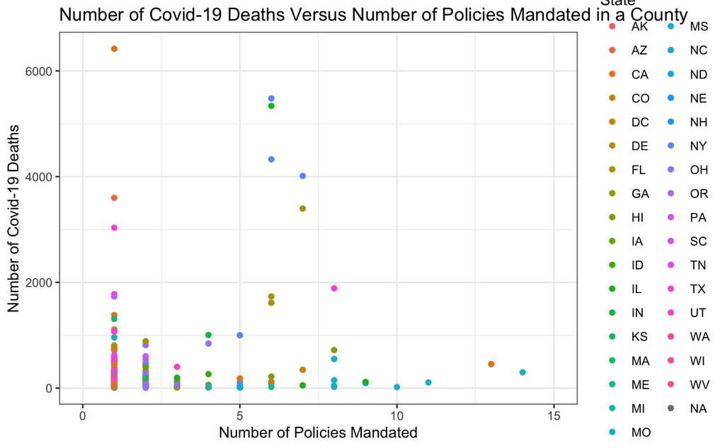

```r
Death_Policy_Var %>%
  ggplot(aes(x = PolicyInvolved, y = Deaths.involving.COVID.19) ) +
  geom_point(aes(color = State) ) +
  labs(x = "Number of Policies Mandated", y = "Number of Covid-19 Deaths") +
  xlim(0,15) +
  ggtitle("Number of Covid-19 Deaths Versus Number of Policies Mandated in a County") +
  theme_bw()
```

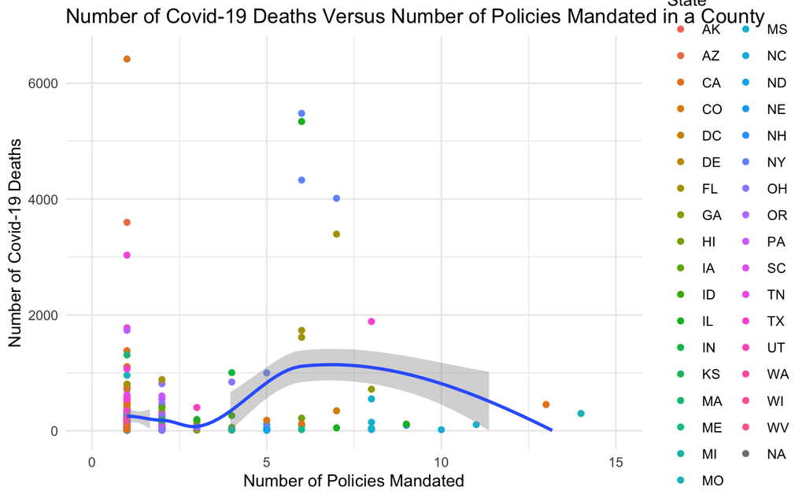

```r
Death_Policy_Var %>%
  ggplot(aes(x = PolicyInvolved, y = Deaths.involving.COVID.19) ) +
  geom_point(aes(color = State) ) +
  geom_smooth() +
  labs(x = "Number of Policies Mandated", y = "Number of Covid-19 Deaths") +
  xlim(0,15) +
  ylim(0,6500) +
  ggtitle("Number of Covid-19 Deaths Versus Number of Policies Mandated in a County") +
  theme_minimal()
```

- From this graph, we can see that the counties with 5-8 policies have the highest Covid-19 deaths on average and those counties with 10-15 policies have higher Covid-19 deaths than those with 1-5 policies on average. But if we take an individual look at the glyphs, this statement is completely false. This is tally with the large width of confidence bands for 8-14 number of policies mandated. Again, there is no correlation between the number of Covid-19 deaths and the number of policies mandated we can say at this point.

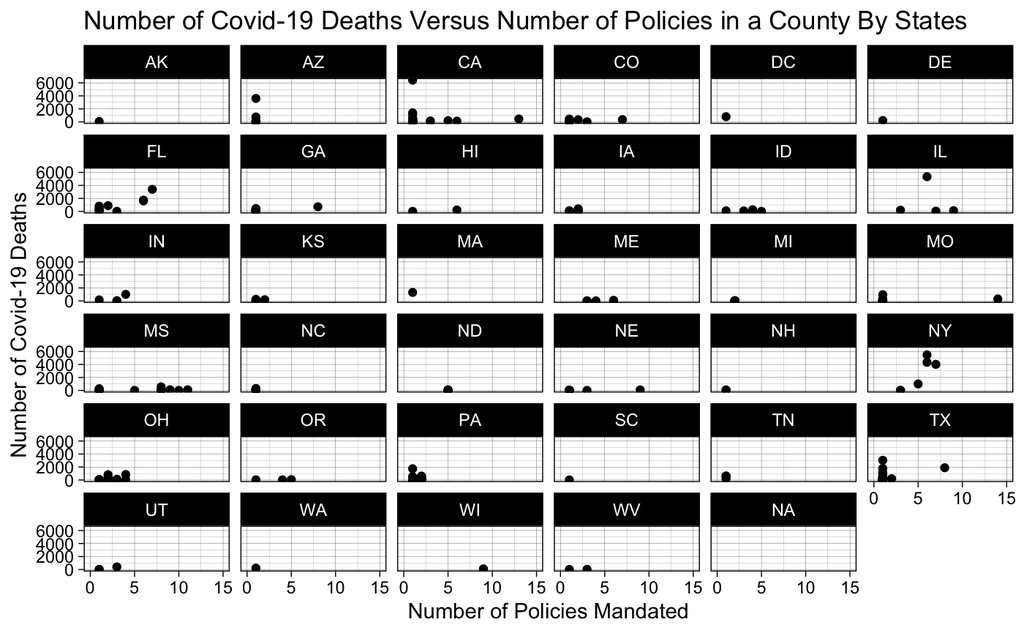

```r
Death_Policy_Var %>%
  ggplot(aes(x = PolicyInvolved, y = Deaths.involving.COVID.19) ) +
  geom_point() +
  facet_wrap(~ State) +
  labs(x = "Number of Policies Mandated", y="Number of Covid-19 Deaths") +
  xlim(0,15) +
  ggtitle("Number of Covid-19 Deaths Versus Number of Policies in a County By States") +
  theme_linedraw()
```

### Let’s Look Into The Narrow and Wide Data

```r
DPV_narrow <- # DPV stands for Death_Policy_Var and 'narrow' since it is the narrow version
Death_Policy_Var %>%
  select(County.name, Deaths.involving.COVID.19, PolicyInvolved)

head(DPV_narrow)
```

| County.name | Deaths.involving.COVID.19 | PolicyInvolved |
| --- | --- | --- |
| Ada County | 264 | 4 |
| Adams County | 328 | 2 |
| Alachua County | 248 | 1 |
| Alameda County | 454 | 13 |
| Allegany County | 17 | 3 |
| Allegheny County | 528 | 1 |

```r
DPV_wide <- # DPV stands for Death_Policy_Var and 'wide' since it is the wide version
  DPV_narrow %>%
  pivot_wider(names_from = PolicyInvolved, values_from = Deaths.involving.COVID.19)

head(DPV_wide)
```

| County.name | 4 | 2 | 1 | 13 | 3 | 8 | 5 | 6 | 9 | 7 | 14 | 11 | 10 | 60 |
| --- | --- | --- | --- | --- | --- | --- | --- | --- | --- | --- | --- | --- | --- | --- |
| Ada County | 264 | NA | NA | NA | NA | NA | NA | NA | NA | NA | NA | NA | NA | NA |
| Adams County | NA | 328 | NA | NA | NA | NA | NA | NA | NA | NA | NA | NA | NA | NA |
| Alachua County | NA | NA | 248 | NA | NA | NA | NA | NA | NA | NA | NA | NA | NA | NA |
| Alameda County | NA | NA | NA | 454 | NA | NA | NA | NA | NA | NA | NA | NA | NA | NA |
| Allegany County | NA | NA | NA | NA | 17 | NA | NA | NA | NA | NA | NA | NA | NA | NA |
| Allegheny County | NA | NA | 528 | NA | NA | NA | NA | NA | NA | NA | NA | NA | NA | NA |

- From the DPV_wide data, I can see that the number of Covid-19 death tolls does not correspond to the number of Covid-19 policies mandated in a county. For example, Alameda County with 454 death cases has 13 policies implemented, while Allegheny County with 528 death cases only has 1 policy. Not just that, Allegany which has 17 death cases has 2 more policies compared to Allegheny County, which its death cases is way more striking than Allegany.

## Challenge Encountered & Resolutions

- Challenges: There are so many other variables I have to consider in this research, for example, the dates of the policy first mandated and the number of deaths from Covid-19 as the time passes.
- Which means, once a policy is mandated, it will not show an instantaneous results as we might think. It probably takes at least 2-3 weeks for the result (of increases/decreases) to show after the policy is implemented.
- Resolution: I observe the trends by each states, divide the total population into 5 clusters, and adapt one statistical analysis method, only then make various conclusions based on the trends and take each of the findings into account of factors before making any general conclusion as a whole.

## Strategy 1: Use Not So Simple Random Sampling Technique, derived from Simple Random Sampling (SRS) Method

- In statistics, SRS is done by selecting n individuals from the population (known as sample size) in such a way that every set of n individuals has an equal chance to be selected.
- But in this project, I choose to use ‘regex’ with random conditions to choose the sample size of n rather than using any device or software to do it for me, mainly for the learning purpose experience. Thus, I name it as Not So Simple Random Sampling.
- But I still follow the general rule which states that the sample sizes must be equal to or greater than 30 to assume that the distribution of the sample means is fairly normally distributed.
- By that, I will set some random conditions in ‘regex’ during the sample size selection process until it reaches 30 or more.

### Step 1: I need to remove the “County” and “Borough” word first in each column (since I want the county/borough name solely for this entire n selection process)

```r
# regex condition is any data in column variable County.name that has word "County" or "Borough" and replace them with "" which means basically nothing so it removes them from the data table

Regex_data <-
Death_Policy_Var %>%
  mutate(County.name = gsub(pattern = "County|Borough", replacement = "", County.name) ) %>%
  na.omit()

head(Regex_data)
```

| Date.as.of | First.week | Last.week | State | County.name | Deaths.involving.COVID.19 | date | PolicyInvolved |
| --- | --- | --- | --- | --- | --- | --- | --- |
| 11/12/2020 | 02/01/2020 | 11/07/2020 | ID | Ada | 264 | 2020-06-24 | 4 |
| 11/12/2020 | 02/01/2020 | 11/07/2020 | CO | Adams | 328 | 2020-03-26 | 2 |
| 11/12/2020 | 02/01/2020 | 11/07/2020 | FL | Alachua | 248 | 2020-03-24 | 1 |
| 11/12/2020 | 02/01/2020 | 11/07/2020 | CA | Alameda | 454 | 2020-05-18 | 13 |
| 11/12/2020 | 02/01/2020 | 11/07/2020 | NY | Allegany | 17 | 2020-06-16 | 3 |
| 11/12/2020 | 02/01/2020 | 11/07/2020 | PA | Allegheny | 528 | 2020-03-23 | 1 |

### Step 2: Sample Size Selection Process

```r
NSSRSSample <-
Regex_data %>%
  filter(grepl("([aeiou]{3,}|^[aeiou]{1}|ox|pe|ds|zo|rd)", County.name, ignore.case = TRUE) )

head(NSSRSSample)
```

| Date.as.of | First.week | Last.week | State | County.name | Deaths.involving.COVID.19 | date | PolicyInvolved |
| --- | --- | --- | --- | --- | --- | --- | --- |
| 11/12/2020 | 02/01/2020 | 11/07/2020 | ID | Ada | 264 | 2020-06-24 | 4 |
| 11/12/2020 | 02/01/2020 | 11/07/2020 | CO | Adams | 328 | 2020-03-26 | 2 |
| 11/12/2020 | 02/01/2020 | 11/07/2020 | FL | Alachua | 248 | 2020-03-24 | 1 |
| 11/12/2020 | 02/01/2020 | 11/07/2020 | CA | Alameda | 454 | 2020-05-18 | 13 |
| 11/12/2020 | 02/01/2020 | 11/07/2020 | NY | Allegany | 17 | 2020-06-16 | 3 |
| 11/12/2020 | 02/01/2020 | 11/07/2020 | PA | Allegheny | 528 | 2020-03-23 | 1 |

### Analysis From Not So Simple Random Sampling

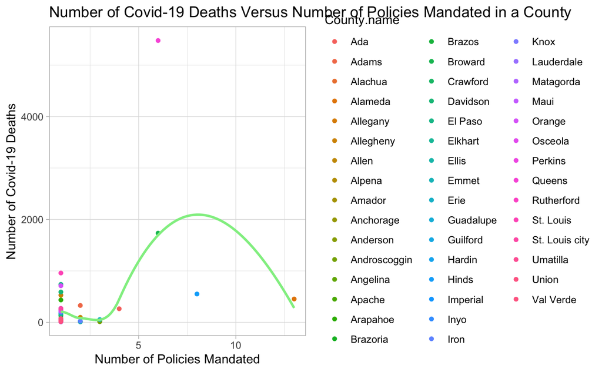

```r
NSSRSSample %>%
  ggplot(aes(x = PolicyInvolved, y = Deaths.involving.COVID.19, color = County.name) ) +
  geom_point(size = 1.3) +
  geom_smooth(se = FALSE, color = "light green") +
  labs(x = "Number of Policies Mandated", y = "Number of Covid-19 Deaths") +
  ggtitle("Number of Covid-19 Deaths Versus Number of Policies Mandated in a County") +
  theme_light()
```

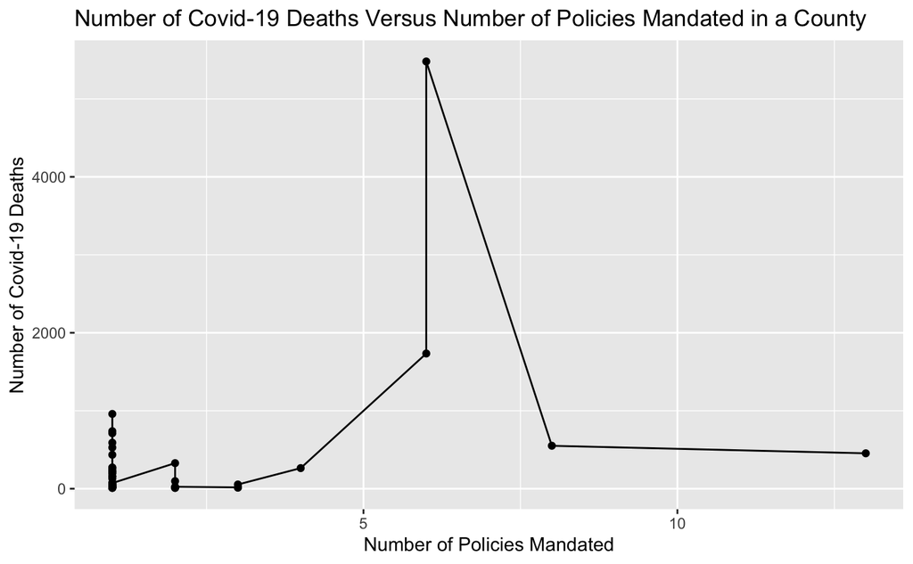

```r
NSSRSSample %>%
  ggplot(aes(x = PolicyInvolved, y = Deaths.involving.COVID.19) ) +
  geom_point() +
  geom_line() +
  labs(x = "Number of Policies Mandated", y = "Number of Covid-19 Deaths") +
  ggtitle("Number of Covid-19 Deaths Versus Number of Policies Mandated in a County")
```

- From the two graphs if I look into the individual glyph, I can say that roughly the counties with low Covid-19 death cases tend to have a higher number of Covid-19 policies, and counties with high Covid-19 death cases tend to have a lower number of Covid-19 policies.
- However, I cannot make that assumption straight as a conclusion, because there are various other factors I have to consider statistically e.g. the proportion of each county (based on the number of Covid-19 policy implemented) in its respective clusters that I will do later in my analysis part.

## Strategy 2: Divide The Counties Into Clusters

- To tackle the challenge encountered as stated earlier, I am going to divide the counties into five categories based on the number of Covid-19 deaths:
- 1. counties with extremely high number of Covid-19 deaths, 3000-6418 deaths.
- 2. counties with high number of Covid-19 deaths, 900-2999 deaths.
- 3. counties with medium number of Covid-19 deaths, 300-899 deaths.
- 4. counties with low number of Covid-19 deaths, 100-299 deaths.
- 5. counties with extremely low number of Covid-19 deaths, 0-99 deaths.
- Then from there, I will be observing each trend in the clusters corresponding to the number of Covid-19 policies involved.

```r
median(Covid19$Deaths.involving.COVID.19)
```

```
[1] 39
```

```r
mean(Covid19$Deaths.involving.COVID.19)
```

```
[1] 169.8362
```

```r
range(Covid19$Deaths.involving.COVID.19)
```

```
[1]   10 6418
```

- We see that the mean of Covid-19 deaths is 170 (after round up to one decimal place), the median is 39, the minimum is 10 and the maximum is 6418.

### Cluster 1: counties with extremely high number of Covid-19 deaths

```r
# 3000-6418 deaths

Cluster1 <-
  Death_Policy_Var %>%
  filter(Deaths.involving.COVID.19 >= 3000 & Deaths.involving.COVID.19 <= 6418) %>%
  arrange(desc(Deaths.involving.COVID.19) )

head(Cluster1)
```

| Date.as.of | First.week | Last.week | State | County.name | Deaths.involving.COVID.19 | date | PolicyInvolved |
| --- | --- | --- | --- | --- | --- | --- | --- |
| 11/12/2020 | 02/01/2020 | 11/07/2020 | CA | Los Angeles County | 6418 | 2020-03-21 | 1 |
| 11/12/2020 | 02/01/2020 | 11/07/2020 | NY | Queens County | 5480 | 2020-06-08 | 6 |
| 11/12/2020 | 02/01/2020 | 11/07/2020 | IL | Cook County | 5339 | 2020-03-21 | 6 |
| 11/12/2020 | 02/01/2020 | 11/07/2020 | NY | Bronx County | 4328 | 2020-06-08 | 6 |
| 11/12/2020 | 02/01/2020 | 11/07/2020 | NY | New York County | 4014 | 2020-06-08 | 7 |
| 11/12/2020 | 02/01/2020 | 11/07/2020 | AZ | Maricopa County | 3599 | 2020-08-27 | 1 |

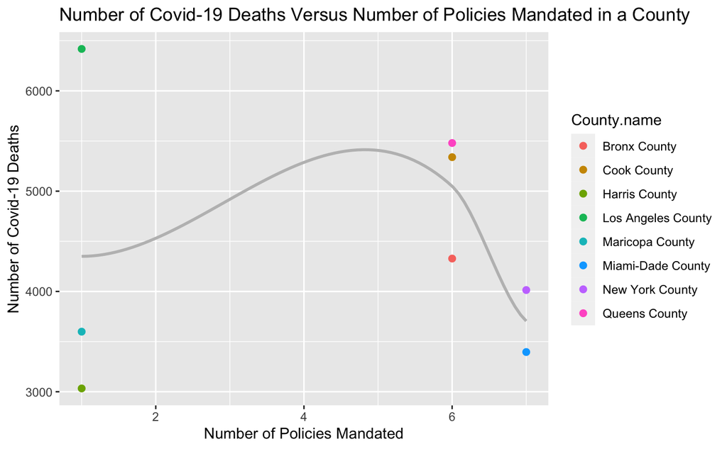

```r
Cluster1 %>%
  ggplot(aes(x = PolicyInvolved, y = Deaths.involving.COVID.19, color = County.name) ) +
  geom_point(size = 2) +
  geom_smooth(se = FALSE, color = "grey") +
  labs(x = "Number of Policies Mandated", y = "Number of Covid-19 Deaths") +
  ggtitle("Number of Covid-19 Deaths Versus Number of Policies Mandated in a County")
```

```r
Cluster1 %>%
  group_by(PolicyInvolved) %>%
  summarise(total = n() )
```

| PolicyInvolved | total |
| --- | --- |
| 1 | 3 |
| 6 | 3 |
| 7 | 2 |

- We can see from the graph that there are 3 counties (Harris, Maricopa, Los Angeles) with only 1 policy mandated although the death tolls from the Covid-19 in those counties are among the highest in the country. Also, the other 5 counties have 6-7 number of Covid-19 policies mandated.
- In this scenario, we can say that majority of the counties in the extremely high number of Covid-19 deaths is implementing 6-7 Covid-19 policies.

```r
Cluster1diffs<- dist(Cluster1)
```

```
NAs introduced by coercion
```

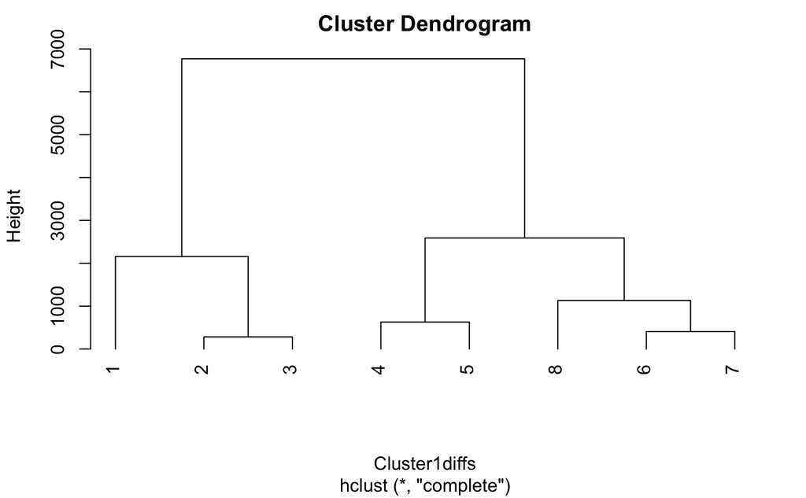

```r
hc1 <- hclust(Cluster1diffs)
plot(hc1, hang = -1)
```

- My main purpose of graphing this cluster dendrogram is to give some insights into how similar or different the elements in the first cluster.
- From the Cluster Dendrogram above, we can see that there are six clades (branch) and eight leaves.
- The height of the branch points indicates how similar or different they are from each other: the greater the height, the greater the difference.

### Cluster 2: counties with high number of Covid-19 deaths

```r
# 900-2999 deaths

Cluster2 <-
  Death_Policy_Var %>%
  filter(Deaths.involving.COVID.19 >= 900 & Deaths.involving.COVID.19 <= 2999) %>%
  arrange(desc(Deaths.involving.COVID.19) )

head(Cluster2)
```

| Date.as.of | First.week | Last.week | State | County.name | Deaths.involving.COVID.19 | date | PolicyInvolved |
| --- | --- | --- | --- | --- | --- | --- | --- |
| 11/12/2020 | 02/01/2020 | 11/07/2020 | TX | Bexar County | 1887 | 2020-05-19 | 8 |
| 11/12/2020 | 02/01/2020 | 11/07/2020 | TX | Hidalgo County | 1777 | 2020-03-26 | 1 |
| 11/12/2020 | 02/01/2020 | 11/07/2020 | PA | Philadelphia County | 1735 | 2020-06-26 | 1 |
| 11/12/2020 | 02/01/2020 | 11/07/2020 | FL | Broward County | 1734 | 2020-05-18 | 6 |
| 11/12/2020 | 02/01/2020 | 11/07/2020 | FL | Palm Beach County | 1614 | 2020-07-03 | 6 |
| 11/12/2020 | 02/01/2020 | 11/07/2020 | CA | Riverside County | 1383 | 2020-04-04 | 1 |

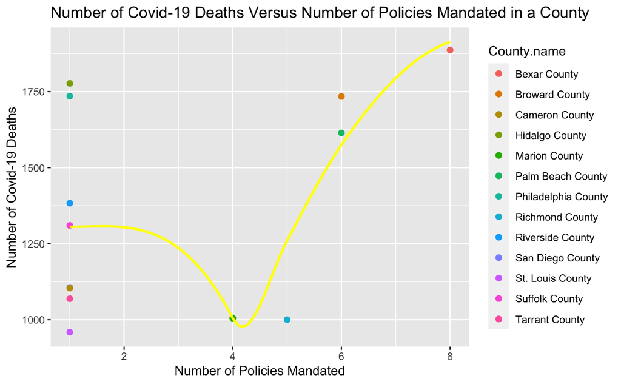

```r
Cluster2 %>%
  ggplot(aes(x = PolicyInvolved, y = Deaths.involving.COVID.19, color = County.name) ) +
  geom_point(size = 2) +
  geom_smooth(se = FALSE, color = "yellow") +
  labs(x = "Number of Policies Mandated", y = "Number of Covid-19 Deaths") +
  ggtitle("Number of Covid-19 Deaths Versus Number of Policies Mandated in a County")
```

```r
Cluster2 %>%
  group_by(PolicyInvolved) %>%
  summarise(total = n() )
```

| PolicyInvolved | total |
| --- | --- |
| 1 | 8 |
| 4 | 1 |
| 5 | 1 |
| 6 | 2 |
| 8 | 1 |

```r
Cluster2diffs<- dist(Cluster2)
```

```
NAs introduced by coercion
```

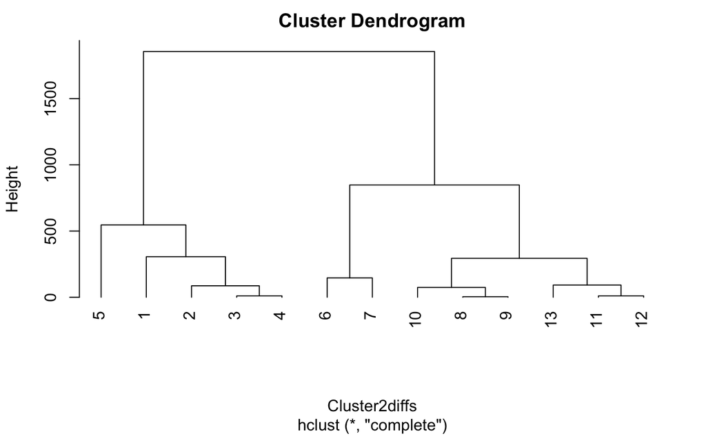

```r
hc2 <- hclust(Cluster2diffs)
plot(hc2, hang = -1)
```

- My main purpose of graphing this cluster dendrogram is to give some insights into how similar or different the elements in the second cluster.
- From the Cluster Dendrogram above, we can see that there are 10 clades (branch) and 13 leaves.
- The height of the branch points indicates how similar or different they are from each other: the greater the height, the greater the difference.

### Cluster 3: counties with medium number of Covid-19 deaths

```r
# 300-899 deaths

Cluster3 <-
  Death_Policy_Var %>%
  filter(Deaths.involving.COVID.19 >= 300 & Deaths.involving.COVID.19 <= 899) %>%
  arrange(desc(Deaths.involving.COVID.19) )

head(Cluster3)
```

| Date.as.of | First.week | Last.week | State | County.name | Deaths.involving.COVID.19 | date | PolicyInvolved |
| --- | --- | --- | --- | --- | --- | --- | --- |
| 11/12/2020 | 02/01/2020 | 11/07/2020 | FL | Hillsborough County | 885 | 2020-03-27 | 2 |
| 11/12/2020 | 02/01/2020 | 11/07/2020 | OH | Franklin County | 843 | 2020-07-23 | 4 |
| 11/12/2020 | 02/01/2020 | 11/07/2020 | OH | Cuyahoga County | 813 | 2020-07-08 | 2 |
| 11/12/2020 | 02/01/2020 | 11/07/2020 | FL | Pinellas County | 806 | 2020-03-26 | 1 |
| 11/12/2020 | 02/01/2020 | 11/07/2020 | DC | District of Columbia | 800 | 2020-03-23 | 1 |
| 11/12/2020 | 02/01/2020 | 11/07/2020 | AZ | Pima County | 752 | 2020-08-27 | 1 |

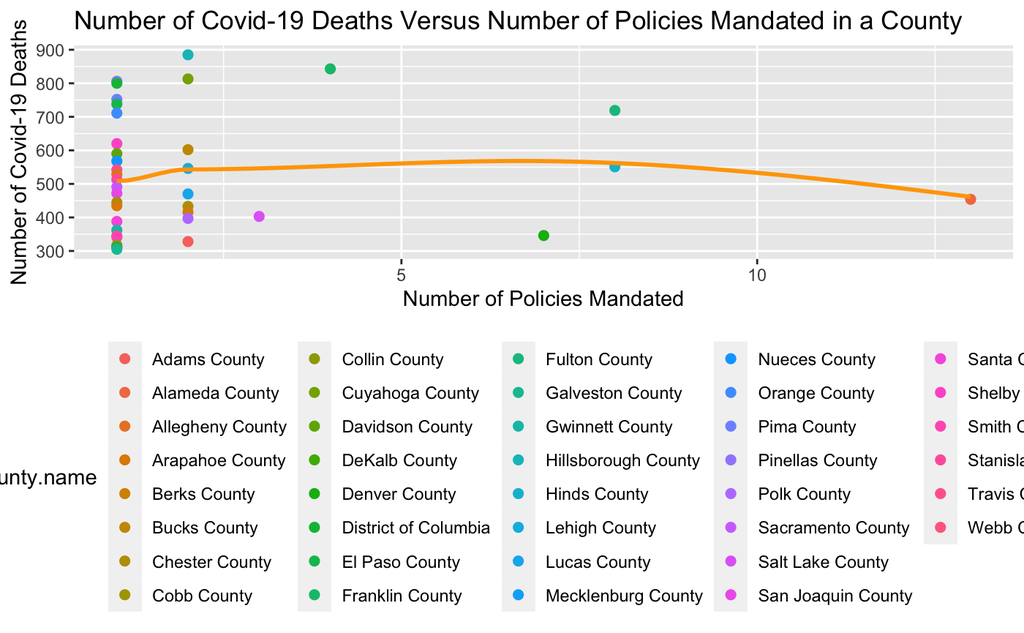

```r
Cluster3 %>%
  ggplot(aes(x = PolicyInvolved, y = Deaths.involving.COVID.19, color = County.name) ) +
  geom_point(size = 2) +
  geom_smooth(se = FALSE, color = "orange") +
  labs(x = "Number of Policies Mandated", y = "Number of Covid-19 Deaths") +
  ggtitle("Number of Covid-19 Deaths Versus Number of Policies Mandated in a County") +
  theme(legend.position = "bottom")
```

```r
Cluster3 %>%
  group_by(PolicyInvolved) %>%
  summarise(total = n() )
```

| PolicyInvolved | total |
| --- | --- |
| 1 | 23 |
| 2 | 9 |
| 3 | 1 |
| 4 | 1 |
| 7 | 1 |
| 8 | 2 |
| 13 | 1 |

- From the graph, we can see that majority of the counties are implementing only 1-2 policies (with 23 of the counties are having 1 policy). There are only 6 counties that have policies from range 3 to 13. The county that has 13 Covid-19 policies is Alameda County, California.
- In this case, we can say that majority of the counties with a medium number of Covid-19 deaths are implementing only 1 Covid-19 policy.

```r
Cluster3diffs<- dist(Cluster3)
```

```
NAs introduced by coercion
```

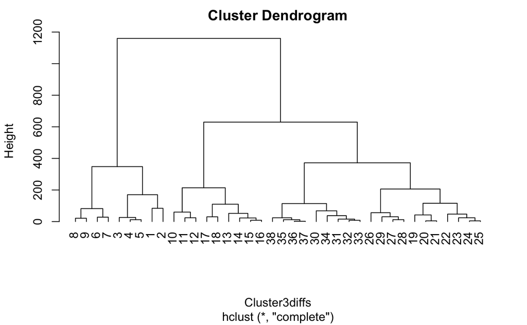

```r
hc3 <- hclust(Cluster3diffs)
plot(hc3, hang = -1)
```

- My main purpose of graphing this cluster dendrogram is to give some insights into how similar or different the elements in the third cluster.
- From the Cluster Dendrogram above, we can see that there are 35 clades (branch) and 38 leaves.
- The height of the branch points indicates how similar or different they are from each other: the greater the height, the greater the difference.

### Cluster 4: counties with low number of Covid-19 deaths

```r
# 100-299 deaths.

Cluster4 <-
  Death_Policy_Var %>%
  filter(Deaths.involving.COVID.19 >= 100 & Deaths.involving.COVID.19 <= 299) %>%
  arrange(desc(Deaths.involving.COVID.19) )

head(Cluster4)
```

| Date.as.of | First.week | Last.week | State | County.name | Deaths.involving.COVID.19 | date | PolicyInvolved |
| --- | --- | --- | --- | --- | --- | --- | --- |
| 11/12/2020 | 02/01/2020 | 11/07/2020 | MO | Jackson County | 299 | 2020-05-11 | 14 |
| 11/12/2020 | 02/01/2020 | 11/07/2020 | CO | Jefferson County | 284 | 2020-03-26 | 1 |
| 11/12/2020 | 02/01/2020 | 11/07/2020 | PA | Northampton County | 284 | 2020-03-25 | 2 |
| 11/12/2020 | 02/01/2020 | 11/07/2020 | TX | Fort Bend County | 275 | 2020-03-25 | 1 |
| 11/12/2020 | 02/01/2020 | 11/07/2020 | MS | Lauderdale County | 271 | 2020-03-31 | 1 |
| 11/12/2020 | 02/01/2020 | 11/07/2020 | MO | St. Louis city | 270 | 2020-03-23 | 1 |

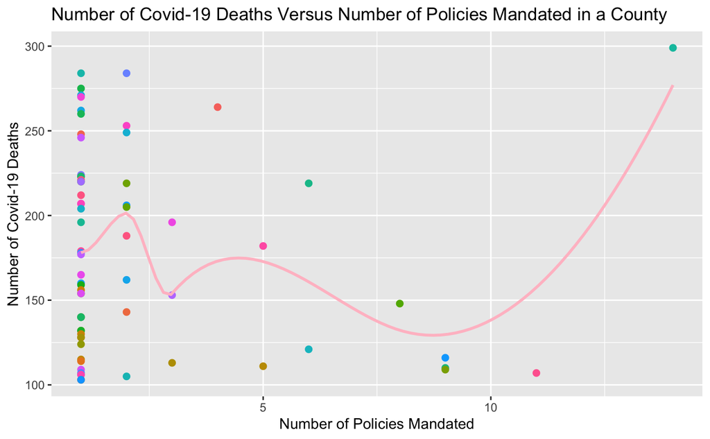

```r
Cluster4 %>%
  ggplot(aes(x = PolicyInvolved, y = Deaths.involving.COVID.19, color = County.name) ) +
  geom_point(size = 2) +
  geom_smooth(se = FALSE, color = "pink") +
  theme(legend.position = "nowhere") + # I choose "nowhere" since the total of counties are 69 which the graph will shrink with the presence of the legend
  labs(x = "Number of Policies Mandated", y = "Number of Covid-19 Deaths") +
  ggtitle("Number of Covid-19 Deaths Versus Number of Policies Mandated in a County")
```

```r
Cluster4 %>%
  group_by(PolicyInvolved) %>%
  summarise(total = n() )
```

| PolicyInvolved | total |
| --- | --- |
| 1 | 45 |
| 2 | 10 |
| 3 | 3 |
| 4 | 1 |
| 5 | 2 |
| 6 | 2 |
| 8 | 1 |
| 9 | 3 |
| 11 | 1 |
| 14 | 1 |

- From this graph, we can see that majority of the counties (45 of them) are implementing 1 Covid-19 policy. Also, there are 8 counties that have a range of 6 to 14 Covid-19 policies.
- In this scenario, we can say that majority of the counties with a low number of Covid-19 deaths are implementing only 1 Covid-19 policy.

```r
Cluster4diffs<- dist(Cluster4)
```

```
NAs introduced by coercion
```

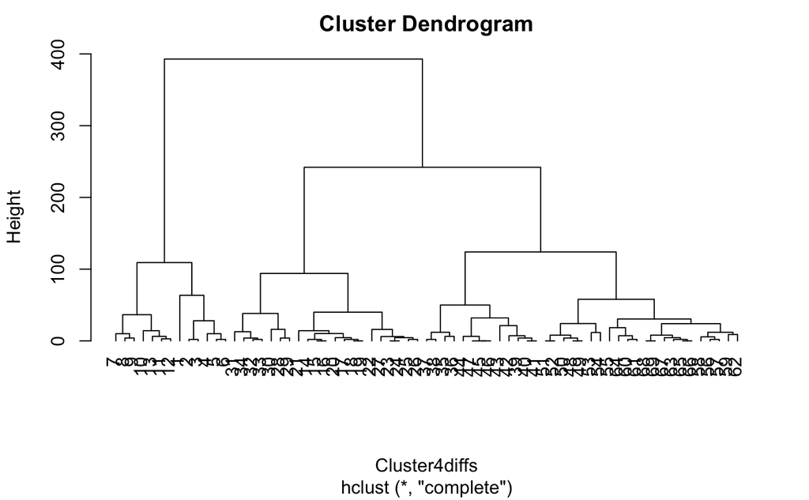

```r
hc4 <- hclust(Cluster4diffs)
plot(hc4, hang = -1)
```

### Cluster 5: counties with extremely low number of Covid-19 deaths

```r
# 0-99 deaths.

Cluster5 <-
  Death_Policy_Var %>%
  filter(Deaths.involving.COVID.19 >= 0 & Deaths.involving.COVID.19 <= 99) %>%
  arrange(desc(Deaths.involving.COVID.19) )

head(Cluster5)
```

| Date.as.of | First.week | Last.week | State | County.name | Deaths.involving.COVID.19 | date | PolicyInvolved |
| --- | --- | --- | --- | --- | --- | --- | --- |
| 11/12/2020 | 02/01/2020 | 11/07/2020 | PA | Westmoreland County | 98 | 2020-03-27 | 1 |
| 11/12/2020 | 02/01/2020 | 11/07/2020 | OH | Allen County | 97 | 2020-07-23 | 2 |
| 11/12/2020 | 02/01/2020 | 11/07/2020 | NC | Cabarrus County | 96 | 2020-03-26 | 1 |
| 11/12/2020 | 02/01/2020 | 11/07/2020 | NE | Lancaster County | 95 | 2020-09-14 | 9 |
| 11/12/2020 | 02/01/2020 | 11/07/2020 | KS | Shawnee County | 94 | 2020-03-26 | 1 |
| 11/12/2020 | 02/01/2020 | 11/07/2020 | ID | Canyon County | 93 | 2020-10-27 | 1 |

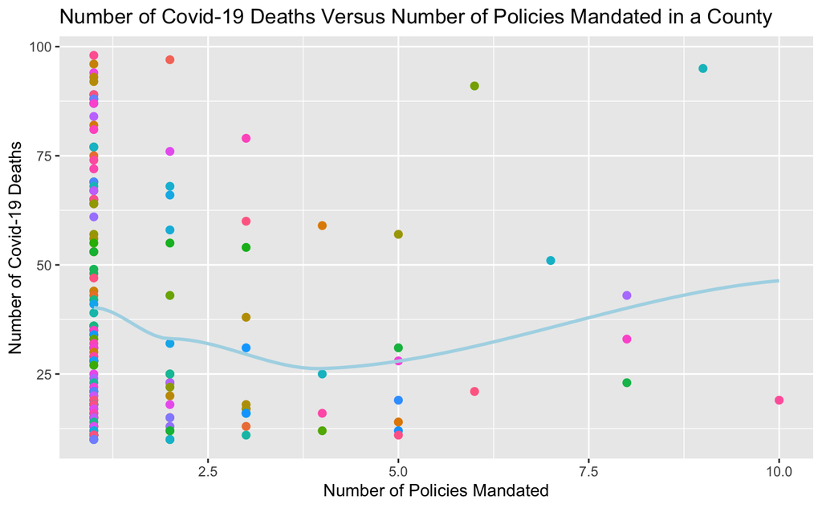

```r
Cluster5 %>%
  ggplot(aes(x = PolicyInvolved, y = Deaths.involving.COVID.19, color = County.name) ) +
  geom_point(size = 2) +
  geom_smooth(se = FALSE, color = "light blue") +
  theme(legend.position = "nowhere") + # I choose "nowhere" since the total of counties are 163 which the graph will shrink with the presence of the legend
  labs(x = "Number of Policies Mandated", y = "Number of Covid-19 Deaths") +
  ggtitle("Number of Covid-19 Deaths Versus Number of Policies Mandated in a County")
```

```r
Cluster5 %>%
  group_by(PolicyInvolved) %>%
  summarise(total = n() )
```

| PolicyInvolved | total |
| --- | --- |
| 1 | 108 |
| 2 | 23 |
| 3 | 13 |
| 4 | 4 |
| 5 | 7 |
| 6 | 2 |
| 7 | 1 |
| 8 | 3 |
| 9 | 1 |
| 10 | 1 |

- From this graph, we can see that, again, the majority of the counties is having only 1 Covid-19 policy. The sum of counties with 1 Covid-19 policy is 108, which makes up a proportion of 66.3% from the total population of counties in the extremely low Covid-19 deaths cluster. Also, there are 8 counties in this cluster that have a range of 6 to 10 Covid-19 policies.
- In this case, we can say that majority of the counties with a low number of Covid-19 deaths are implementing only 1 Covid-19 policy.

```r
Cluster5diffs<- dist(Cluster5)
```

```
NAs introduced by coercion
```

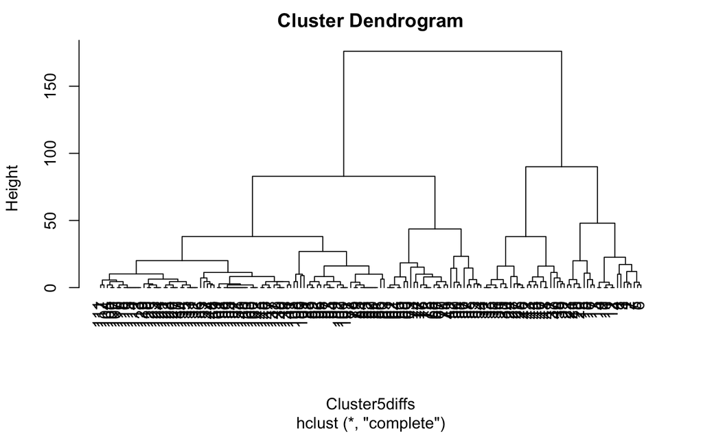

```r
hc5 <- hclust(Cluster5diffs)
plot(hc5, hang = -1)
```

- My main purpose of graphing this cluster dendrogram is to give some insights into how similar or different the elements in the fifth cluster.
- From the Cluster Dendrogram above, we can see that there are more than 70 clades (branch) and more than 90 leaves.
- The height of the branch points indicates how similar or different they are from each other: the greater the height, the greater the difference.
- As a conclusion after dividing the counties into 5 categories process, I can conclude that based on this data, regardless of the total Covid-19 death tolls in any county, the majority of the county is Implementing only 1 Covid-19 policy.

## Finding from Strategy 2: Majority of the County in the United States is Implementing only 1 Covid-19 Policy

- Regardless of the total Covid-19 death tolls in any county, the majority of the county is Implementing only 1 Covid-19 policy.
- The proportion of counties with only 1 Covid-19 policy makes up 64% of the total 292 counties that we have in the data sets (187/292*100= 64%).
- Now let’s find out what is that particular 1 policy that most of the counties are implementing and investigate if the specific policy is effective and reasonable.

```r
County1Policy <-
  Death_Policy_Var %>%
  filter(PolicyInvolved == 1)

head(County1Policy)
```

| Date.as.of | First.week | Last.week | State | County.name | Deaths.involving.COVID.19 | date | PolicyInvolved |
| --- | --- | --- | --- | --- | --- | --- | --- |
| 11/12/2020 | 02/01/2020 | 11/07/2020 | FL | Alachua County | 248 | 2020-03-24 | 1 |
| 11/12/2020 | 02/01/2020 | 11/07/2020 | PA | Allegheny County | 528 | 2020-03-23 | 1 |
| 11/12/2020 | 02/01/2020 | 11/07/2020 | CA | Amador County | 28 | 2020-03-20 | 1 |
| 11/12/2020 | 02/01/2020 | 11/07/2020 | AK | Anchorage Borough | 53 | 2020-03-22 | 1 |
| 11/12/2020 | 02/01/2020 | 11/07/2020 | TX | Anderson County | 34 | 2020-04-02 | 1 |
| 11/12/2020 | 02/01/2020 | 11/07/2020 | TX | Angelina County | 75 | 2020-03-30 | 1 |

```r
PolicyTypeofCounty1Policy <-
  Death_Policy %>%
  right_join(County1Policy, by = "County.name")

head(PolicyTypeofCounty1Policy)
```

|  | Date.as.of.x | First.week.x | Last.week.x | State.x | County.name | FIPS.County.Code | Urban.Rural.Code | Deaths.involving.COVID.19.x | Deaths.from.All.Causes | state_id | county | policy_level | date.x | policy_type | start_stop | comments | source | total_phases | Date.as.of.y | First.week.y | Last.week.y | State.y | Deaths.involving.COVID.19.y | date.y | PolicyInvolved |
| --- | --- | --- | --- | --- | --- | --- | --- | --- | --- | --- | --- | --- | --- | --- | --- | --- | --- | --- | --- | --- | --- | --- | --- | --- | --- |
| 1 | 11/12/2020 | 02/01/2020 | 11/07/2020 | AK | Anchorage Borough | 2020 | Medium metro | 53 | 1622 | AK | Anchorage Municipality | county | 2020-03-22 | Shelter in Place | start | Anchorage Municipality Policy Start | wikidata | NA | 11/12/2020 | 02/01/2020 | 11/07/2020 | AK | 53 | 2020-03-22 | 1 |
| 2 | 11/12/2020 | 02/01/2020 | 11/07/2020 | AZ | Apache County | 4001 | Noncore | 43 | 430 | AZ | Apache | county | 2020-08-27 | Outdoor and Recreation | start | Policy_Details: Indoor gyms and fitness centers in Apache, Cochise, Coconino, La Paz, Maricopa, Navajo, Pima and Yavapai counties may attest to reopen in compliance with ADHS COVID-19 Guidelines inclu… | sip_submission_form: https://directorsblog.health.azdhs.gov/positive-news-for-az-counties-in-the-moderate-transmission-level-moving-into-next-phase-of-safely-reopening/ | 3 | 11/12/2020 | 02/01/2020 | 11/07/2020 | AZ | 43 | 2020-08-27 | 1 |
| 3 | 11/12/2020 | 02/01/2020 | 11/07/2020 | AZ | Cochise County | 4003 | Small metro | 31 | 866 | AZ | Cochise | county | 2020-08-27 | Outdoor and Recreation | start | Policy_Details: Indoor gyms and fitness centers in Apache, Cochise, Coconino, La Paz, Maricopa, Navajo, Pima and Yavapai counties may attest to reopen in compliance with ADHS COVID-19 Guidelines inclu… | sip_submission_form: https://directorsblog.health.azdhs.gov/positive-news-for-az-counties-in-the-moderate-transmission-level-moving-into-next-phase-of-safely-reopening/ | 3 | 11/12/2020 | 02/01/2020 | 11/07/2020 | AZ | 31 | 2020-08-27 | 1 |
| 4 | 11/12/2020 | 02/01/2020 | 11/07/2020 | AZ | Coconino County | 4005 | Small metro | 132 | 1006 | AZ | Coconino | county | 2020-08-27 | Outdoor and Recreation | start | Policy_Details: Indoor gyms and fitness centers in Apache, Cochise, Coconino, La Paz, Maricopa, Navajo, Pima and Yavapai counties may attest to reopen in compliance with ADHS COVID-19 Guidelines inclu… | sip_submission_form: https://directorsblog.health.azdhs.gov/positive-news-for-az-counties-in-the-moderate-transmission-level-moving-into-next-phase-of-safely-reopening/ | 3 | 11/12/2020 | 02/01/2020 | 11/07/2020 | AZ | 132 | 2020-08-27 | 1 |
| 5 | 11/12/2020 | 02/01/2020 | 11/07/2020 | AZ | Maricopa County | 4013 | Large central metro | 3599 | 33604 | AZ | Maricopa | county | 2020-08-27 | Outdoor and Recreation | start | Policy_Details: Indoor gyms and fitness centers in Apache, Cochise, Coconino, La Paz, Maricopa, Navajo, Pima and Yavapai counties may attest to reopen in compliance with ADHS COVID-19 Guidelines inclu… | sip_submission_form: https://directorsblog.health.azdhs.gov/positive-news-for-az-counties-in-the-moderate-transmission-level-moving-into-next-phase-of-safely-reopening/ | 3 | 11/12/2020 | 02/01/2020 | 11/07/2020 | AZ | 3599 | 2020-08-27 | 1 |
| 6 | 11/12/2020 | 02/01/2020 | 11/07/2020 | AZ | Navajo County | 4017 | Micropolitan | 69 | 854 | AZ | Navajo | county | 2020-08-27 | Outdoor and Recreation | start | Policy_Details: Indoor gyms and fitness centers in Apache, Cochise, Coconino, La Paz, Maricopa, Navajo, Pima and Yavapai counties may attest to reopen in compliance with ADHS COVID-19 Guidelines inclu… | sip_submission_form: https://directorsblog.health.azdhs.gov/positive-news-for-az-counties-in-the-moderate-transmission-level-moving-into-next-phase-of-safely-reopening/ | 3 | 11/12/2020 | 02/01/2020 | 11/07/2020 | AZ | 69 | 2020-08-27 | 1 |

```r
PolicyTypeofCounty1Policy %>%
  group_by(policy_type) %>%
  summarise(total = n() ) %>%
  arrange(desc(total) )
```

| policy_type | total |
| --- | --- |
| Shelter in Place | 166 |
| Outdoor and Recreation | 7 |
| Phase 2 | 7 |
| Food and Drink | 5 |
| Phase 3 | 4 |
| Public Health Advisory System | 3 |
| Mask Requirement | 1 |
| Non-Essential Businesses | 1 |
| Phase 4 | 1 |

- We find that the most common and famous policy type that is implemented by counties with only 1 Covid-19 policy is Shelter in Place, or also known as quarantine order.
- It is indeed the most effective method to protect the citizens from being exposed to the virus and the virus itself from spreading like a wildfire.

## Conclusion From All Findings

From all the analysis process I have done, I can conclude that there is no correlation between the number of Covid-19 deaths and the number of policies implemented in a county. This is because first: each policy addresses a different problem at the county level. Second: from most scientific findings, usually people who died from the Covid-19 virus are people at an old age and people with existing chronic health problems. And last but not least: the authority might look at the number of Covid-19 cases rather looking at the number of death tolls from Covid-19 as the main resource before deciding to implement any new policy.